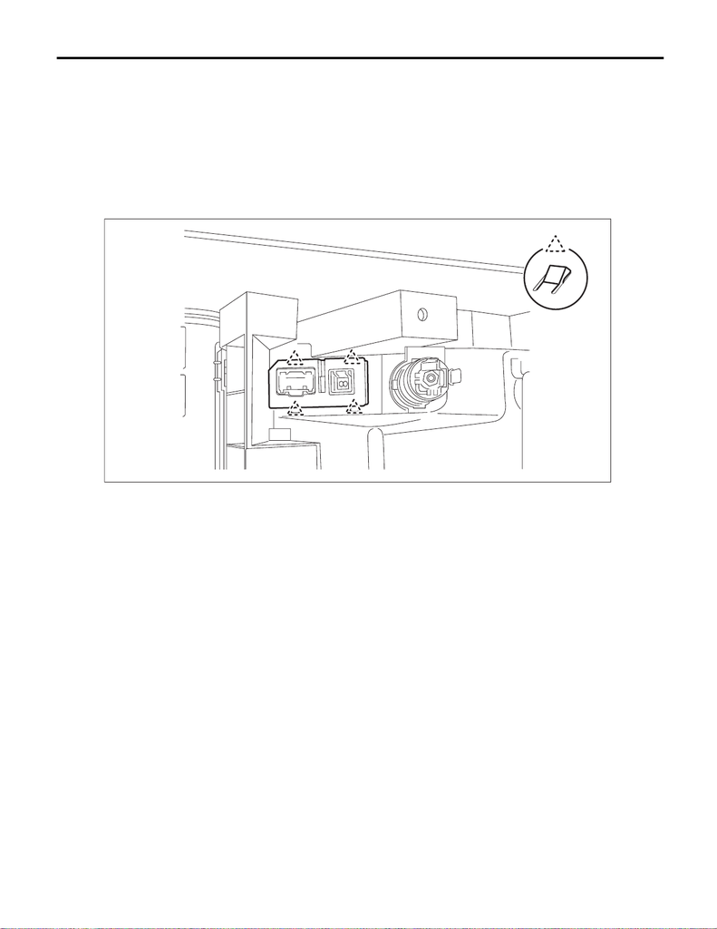

ET-26

AUX Input Terminal

ENTERTAINMENT

18.AUX Input Terminal

A: REMOVAL

1. AUX UNIT

1) Disconnect the ground cable from battery. <Ref. to NT-5, BATTERY, NOTE, Note.>

NOTE:

For models other than STI model, disconnect the ground terminal from battery sensor.

2) Remove the console box assembly. <Ref. to EI-67, REMOVAL, Console Box.>

3) Release the claws, and then remove the unit - AUX terminal.

2. AUX FEEDER CORD

1) Disconnect the ground cable from battery. <Ref. to NT-5, BATTERY, NOTE, Note.>

NOTE:

• On CVT models, shift the select lever into “D” before disconnecting the battery ground cable.

• For models other than STI model, disconnect the ground terminal from battery sensor.

2) Remove the console box. <Ref. to EI-67, REMOVAL, Console Box.>

3) Remove the panel center assembly. <Ref. to EI-66, REMOVAL, Center Console.>

4) Remove the audio assembly or navigation assembly. <Ref. to ET-8, REMOVAL, Audio.>

ET-00917

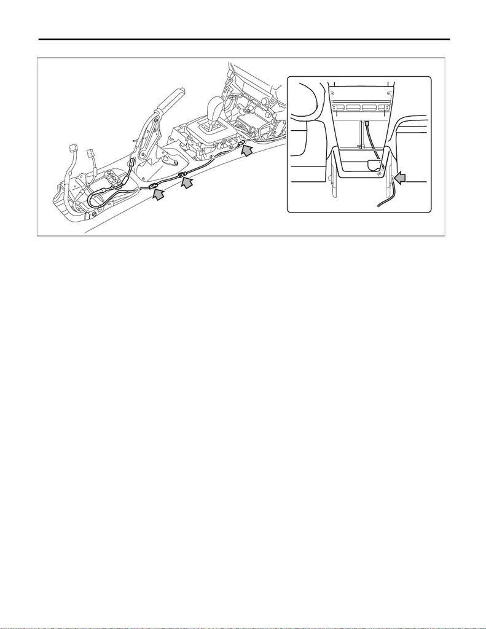

AUX Input Terminal

ENTERTAINMENT

5) Remove the clamps and remove the cord assembly - AUX feeder.

B: INSTALLATION

1. AUX UNIT

1) Install the unit - AUX terminal.

2) Install the console box assembly.

3) Connect the battery ground terminal. <Ref. to NT-5, BATTERY, NOTE, Note.>

NOTE:

For models other than STI model, connect the ground terminal to battery sensor.

2. AUX FEEDER CORD

CAUTION:

After installing the panel center assembly, check that the air vent grille of the panel center assembly

is inserted correctly into the air vent duct.

1) Install the cord assembly - AUX feeder.

2) Install the audio assembly or navigation assembly.

3) Install the panel center assembly.

4) Install the console box.

5) Connect the battery ground terminal. <Ref. to NT-5, BATTERY, NOTE, Note.>

NOTE:

For models other than STI model, connect the ground terminal to battery sensor.

ET-00918

[figure not shown]

AUX Input Terminal

ENTERTAINMENT

[figure not shown]

COMMUNICATION SYSTEM

COM

Page

3. Horn System ..............................................................................................4

4. Horn ...........................................................................................................5

5. Horn Switch ..............................................................................................10